# Validating the *FireEdge* Assessment

Robert W. Szarek

March 10, 2021

This document was created as an R Markdown file from within R-Studio. The benefits of using an R Markdown file for scientific research include the ability to weave code and theory into a single document, all the while providing the reader a clear look into the analyses conducted to reach the various conclusions presented. Such reproducible analyses help make scientific studies more transparent and accessible to stakeholders.

## 1. Overview and Context

A team of I/O Psychologists in an external consulting firm developed the *FireEdge* test as a cognitive and situation-based judgment assessment to hire entry-level firefighters. The analyses contained in this technical document pick up after the *FireEdge* examination was constructed and pilot tested. The final tool is a 150-question exam that takes two hours to administer.

This research study walks the user through a validation study to empirically demonstrate a positive and significant relationship between the test scores on the newly developed *FireEdge* test with supervisory ratings of job performance. The benefits of a successful research study include:

- Marketing *FireEdge* as a proven screening device to select top-performing talent
- Providing a legal framework for using the *FireEdge* for selection
- Demonstrating criterion-related test validity
- Helping minimize bias and ensure the test is fair

For the purposes of testing our hypotheses, we employed three unique statistical techniques:

- Pearson Product Moment Correlation with t-test to establish a correlation
- Ordinary Least Squares (OLS) Linear Regression to model a line of best fit
- Analysis of Variance (ANOVA) to investigate differences in *FireEdge* scores by Race

Our hypotheses were two-fold:

- Establish a significant, positive relationship between *FireEdge* test scores and job performance
- Ensure our *FireEdge* test scores are not biased or skewed across different racial groups

To begin the research study, we load the tidyverse package to ease the manipulation of data and provide an intuitive interface for readers to understand our code structure, as the tidyverse framework is modeled on traditional SQL queries.

```r
library(tidyverse)
```

## 2. Data Import

Once the tidyverse has been loaded, we import the cleaned and scored dataset that contains the necessary variables required for testing the hypotheses associated with the research study. The procedure of cleaning, scoring and refactoring the test data will not be covered in this research study. Instead, we are already provided a finalized version of the dataset. The code below imports the data table into our global R environment.

```r
val_data <- read_rds(file = "~/R-lang/FireEdge/data/FireEdge_data.Rds")
```

The original dataset includes item-level data and dimension-level data in conjunction with various other variables concerning the criteria. As none of this is required to conduct our validation study, we focus on the overall composite score with the criteria of job performance, and drop all remaining variables from the data table. This helps ensure we do not run analyses on incorrect columns at a later point in this analysis.

```r
val_data <-
  val_data %>%
  select(
    Study,
    Gender,
    Race,
    Final_Score,
    Crit_Supv
  ) %>%
  rename(
    "JobPerformance" = Crit_Supv,
    "FireEdge_Score" = Final_Score
  ) %>%
  mutate(Study = as_factor(Study))

str(val_data)
```

```
## tibble [339 × 5] (S3: tbl_df/tbl/data.frame)
##  $ Study         : Factor w/ 3 levels "Maryland","Colorado",..: 1 1 1 1 1 1 1 1 1 1 ...
##  $ Gender        : Factor w/ 2 levels "Male","Female": 1 2 2 2 1 2 2 1 2 2 ...
##  $ Race          : Factor w/ 7 levels "Black","Asian",..: 6 1 1 1 6 3 6 1 6 1 ...
##  $ FireEdge_Score: num [1:339, 1] 66.6 79.5 82.8 82.1 75.9 ...
##  $ JobPerformance: num [1:339] 45 NA 40 47 44 48 49 48 45 46 ...
```

In the condensed data table, we have the following variables:

- **Study** is the location of the agency participating in the validation study.
- **Gender** is the gender identity of the study participant.
- **Race** is the race of the study participant.
- **FireEdge_Score** is the final score on the *FireEdge* test.
- **JobPerformance** is the supervisory rating of job performance.

## 3. Descriptive Statistics

Next, we begin to investigate the descriptive statistics concerning the supervisor ratings of job performance. The code below creates a table of information broken down by Study location, such as the average job performance score, the standard deviation of the distribution, and the minimum and maximum job performance scores

```r
val_data %>%
  group_by(Study) %>%
  summarise(
    .groups = "drop",
    RawTotal = n(),
    Missing = sum(is.na(JobPerformance)),
    True_Sample = RawTotal - Missing,
    Mean = mean(JobPerformance, na.rm = TRUE),
    SD = sd(JobPerformance, na.rm = TRUE),
    Min = min(JobPerformance, na.rm = TRUE),
    Max = max(JobPerformance, na.rm = TRUE)
  )
```

```
## # A tibble: 3 x 8
##   Study    RawTotal Missing True_Sample  Mean    SD   Min   Max
##   <fct>       <int>   <int>       <int> <dbl> <dbl> <dbl> <dbl>
## 1 Maryland       65       2          63  44.4  5.85    25    55
## 2 Colorado      205      13         192  45.4  6.30    26    62
## 3 Alabama        69      27          42  43.5  5.24    30    57
```

We see that the agency in Alabama had a total of 27 missing cases of performance ratings, while the Colorado agency had a total of 13 missing cases. The average job performance ratings are all consistent across the three study locations, as are the standard deviations, minimum and maximum scores. We therefore are able to combine the three agencies together to increase the power of a single, more powerful predictive study. Our next analysis performs a similar operation on the *FireEdge* score.

```r
val_data %>%
  group_by(Study) %>%
  summarise(
    .groups = "drop",
    RawTotal = n(),
    Missing = sum(is.na(FireEdge_Score)),
    True_Sample = RawTotal - Missing,
    Mean = mean(FireEdge_Score, na.rm = TRUE),
    SD = sd(FireEdge_Score, na.rm = TRUE),
    Min = min(FireEdge_Score, na.rm = TRUE),
    Max = max(FireEdge_Score, na.rm = TRUE)
  )
```

```
## # A tibble: 3 x 8
##   Study    RawTotal Missing True_Sample  Mean    SD   Min   Max
##   <fct>       <int>   <int>       <int> <dbl> <dbl> <dbl> <dbl>
## 1 Maryland       65       0          65  75.2  5.56  59.8  84.1
## 2 Colorado      205       0         205  77.6  5.71  49.4  85.6
## 3 Alabama        69       0          69  72.7  8.95  43.8  85.4
```

```r
val_data <-
val_data %>%
  filter(!is.na(JobPerformance))
```

We remove the missing data points and determine we have a total of 297 cases to test our hypotheses with. Next, we create a series of visualizations to determine the number of participants based on Race, Gender and Study that are in our study.

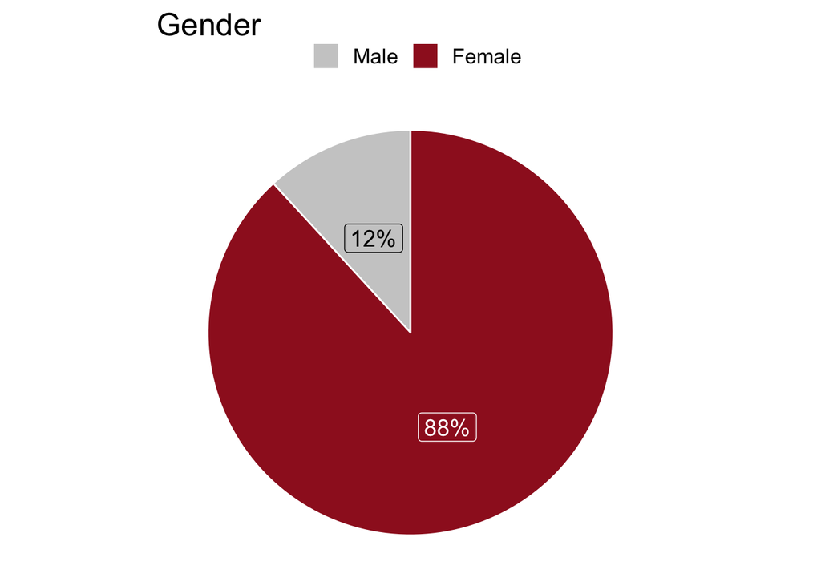

```r
val_data %>%
  count(Gender) %>%
  filter(Gender == "Male" | Gender == "Female") %>%
  mutate(Percentage = scales::percent(n / sum(n))) %>%
  ggplot(aes(x = "", y = n, fill = Gender)) +
  geom_bar(stat = "identity",  color = "white", show.legend = TRUE) +
  coord_polar("y") +
  theme_void(base_size = 16) +
  scale_fill_manual(name= "", values = c("#CCCCCC", "#9E1C24")) +
    labs(x = "",
         y = "",
         title = "Gender") +
  geom_label(aes(label = Percentage), size=5, color = c("black", "white"),
             position = position_stack(vjust=0.5),show.legend = FALSE) +
  theme(legend.position = "top")
```

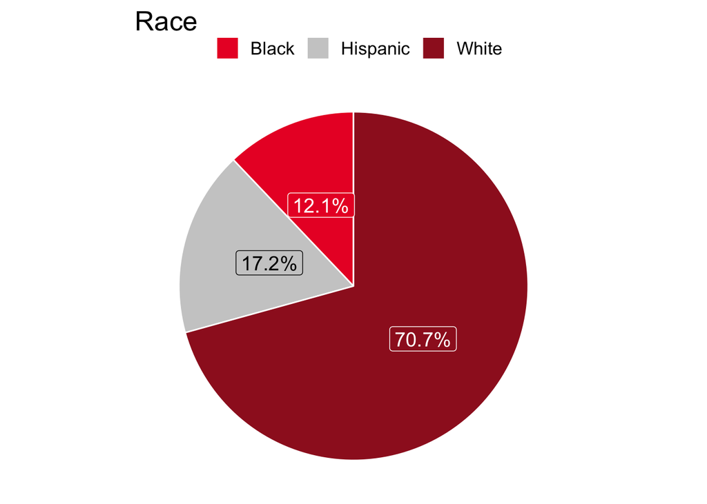

```r
val_data %>%
  count(Race) %>%
  filter(Race == "Hispanic" | Race == "White" | Race == "Black") %>%
  mutate(Percentage = scales::percent(n / sum(n))) %>%
  ggplot(aes(x = "", y = n, fill = Race)) +
  geom_bar(stat = "identity",  color = "white", show.legend = TRUE) +
  coord_polar("y") +
  theme_void(base_size = 16) +
  scale_fill_manual(name= "", values = c( "#EA1D2E", "#CCCCCC", "#9E1C24")) +
    labs(x = "",
         y = "",
         title = "Race") +
  geom_label(aes(label = Percentage), size=5, color = c("white", "black", "white"),
             position = position_stack(vjust=0.5),show.legend = FALSE) +
  theme(legend.position = "top")
```

The final chart outlines the location from which participants were pulled. The majority of participants derived from a firefighting agency located in Colorado, with 64.6% of the total sample. Maryland was next, with 21.2% and Alabama was last, with 14.1%. Such a diverse sample helps ensure we obtain data points from all across the nation. For the purposes of this study, we collapse all three agencies into a single study.

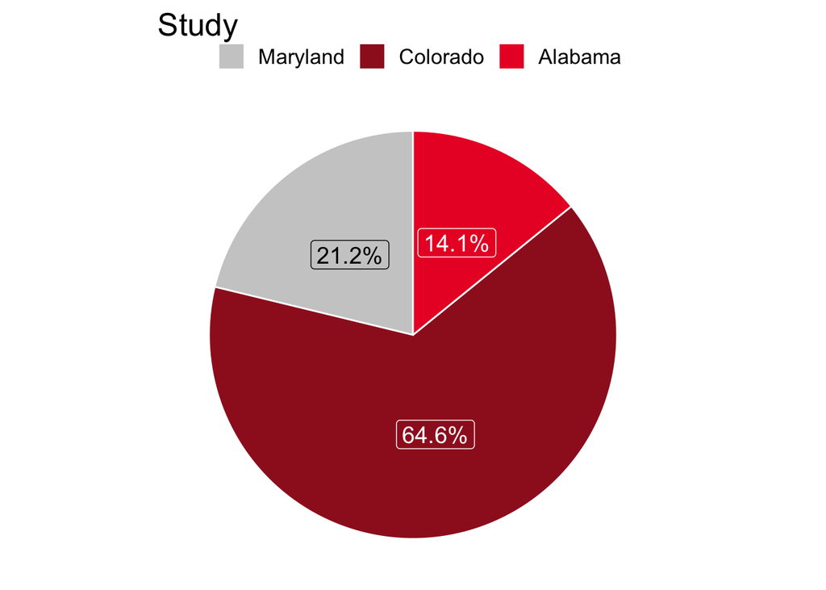

```r
val_data %>%
  count(Study) %>%
  mutate(Percentage = scales::percent(n / sum(n))) %>%
  ggplot(aes(x = "", y = n, fill = Study)) +
  geom_bar(stat = "identity",  color = "white", show.legend = TRUE) +
  coord_polar("y") +
  theme_void(base_size = 16) +
  scale_fill_manual(name= "", values = c("#CCCCCC", "#9E1C24", "#EA1D2E")) +
    labs(x = "",
         y = "",
         title = "Study") +
  geom_label(aes(label = Percentage), size=5, color = c("black", "white", "white"),
             position = position_stack(vjust=0.5),show.legend = FALSE) +
  theme(legend.position = "top")
```

In summary, the sample size obtained for the purposes of this validation study were found to be diverse enough to represent the population in general. Additionally, the sample size itself was found to be adequate for the purposes of statistical significance testing, and we therefore proceed to conducting our various analyses.

## 4. Pearson Correlation Analysis

A correlation coefficient seeks to establish an empirical relationship between two variables. In this case, we seek to measure the level of association between the *FireEdge* test score and job performance ratings. A positive correlation coefficient would indicate that as one variable increases, so does the other. A negative correlation coefficient would indicate that if one variable increases in value, the other variable decreases. In this particular example, a negative relationship would mean that as test scores go up, job performance goes down, a result we definitely would not like to see! We therefore hypothesize that our correlation will yield a significant, positive association between the two variables.

THe results of the analysis are presented below. Specifically, we obtained a correlation coefficient of *r* = .273. We then conducted a Student’s T-test on the value to test whether the obtained correlation is significantly different than zero. The results of the t-test were very significant, *t*(295) = 4.884, *p* < .001. This tells us that the calculated correlation, or relationship between the two variables is significantly different than zero, which helps us gain certainty around the relationship between *FireEdge* test scores and supervisor ratings of job performance.

```r
cor.test(x = val_data$FireEdge_Score,
         y = val_data$JobPerformance,
         exact = TRUE,
         method = "pearson")
```

```
##
##  Pearson's product-moment correlation
##
## data:  val_data$FireEdge_Score and val_data$JobPerformance
## t = 4.8837, df = 295, p-value = 1.71e-06
## alternative hypothesis: true correlation is not equal to 0
## 95 percent confidence interval:
##  0.1648158 0.3756179
## sample estimates:
##       cor
## 0.2734977
```

The confidence interval lets us know that we are 95% confident that our correlation coefficient lies between 0.164 and 0.375. Since this range does **not** include the value 0, the t-test will, by default, be significant. We retain the alternative hypothesis and demonstrate a relationship between test scores on the *FireEdge* and job performance ratings. The linear regression model will further provide a visual means of investigating the degree of this relationship.

## 5. Linear Regression Model

A linear regression model seeks to summarize the relationship between two (or more) variables with a single line of best fit. This line of best fit seeks to minimize the error between an actual observed value and the predicted value, known as a residual. Furthermore, such a relationship could then be used to infer somebody’s job performance rating given their score on the *FireEdge* test. Say, for example, we observe a test score of 85.00%, but do not have a performance rating for a participant who scored an 85%, how would we go about determining their estimated job performance? With linear regression, we’d have a way to impute the 85% into the linear model to obtain an estimated job performance score. The code below runs the linear regression where the *FireEdge* test score is the predictor, or, independent variable. The dependent variable, or outcome variable, is job performance. We seek to predict job performance from a participant’s test score.

```r
summary(
lm(JobPerformance ~ FireEdge_Score,
   data = val_data)
)
```

```
##
## Call:
## lm(formula = JobPerformance ~ FireEdge_Score, data = val_data)
##
## Residuals:
##      Min       1Q   Median       3Q      Max
## -20.1572  -3.4707  -0.2692   3.4955  16.9180
##
## Coefficients:
##                Estimate Std. Error t value Pr(>|t|)
## (Intercept)     24.4378     4.2149   5.798 1.72e-08 ***
## FireEdge_Score   0.2686     0.0550   4.884 1.71e-06 ***
## ---
## Signif. codes:  0 '***' 0.001 '**' 0.01 '*' 0.05 '.' 0.1 ' ' 1
##
## Residual standard error: 5.865 on 295 degrees of freedom
## Multiple R-squared:  0.0748, Adjusted R-squared:  0.07166
## F-statistic: 23.85 on 1 and 295 DF,  p-value: 1.71e-06
```

The linear regression model looks promising when we inspect the regression results. Including the *FireEdge* score as a predictor had a significant t-test value of *t* = 4.884, *p* < .000 (a similar value to what we saw in the correlation analysis - for good reason, they are nearly the same test here). The multiple r-squared was unfortunately not that high, with only .07 of the observed variance being explained by the predictor. The overall F-test was additionally significant, indicating that the model as a whole was significant at*p* < .000. The visualization below shows the extent of the relationship in addition with the relevant histograms for each of the two variables drawn in the margins. We see that the *FireEdge* test scores are negatively skewed, with a significant portion of scores on the higher end of the scale. The job performance ratings followed a more normal distribution.

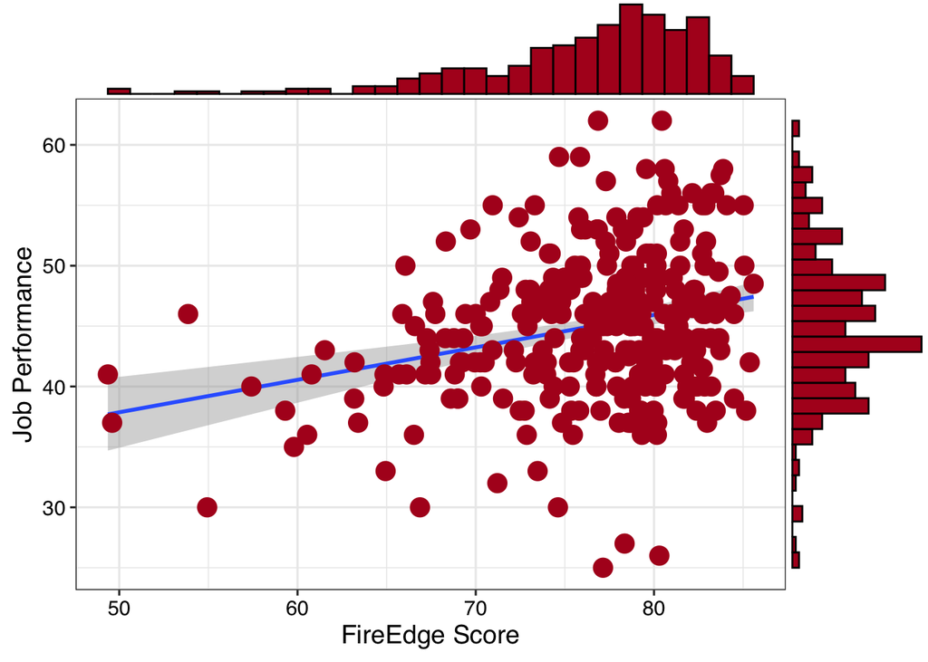

```r
lin_reg_graph <-
ggplot(val_data, aes(FireEdge_Score, JobPerformance)) +
  geom_point(size = 4, color = "black") +
  geom_smooth(method = "lm", se = TRUE) +
  labs(y = "Job Performance",
       x = "FireEdge Score") +
  geom_point(size = 4.5, color = "#B11822") +
  theme_bw(base_family = "sans", base_size = 12) +
  theme(text = element_text(size = 14),
        axis.text = element_text(colour = "black"))

lin_reg_graph_final <-
  ggExtra::ggMarginal(lin_reg_graph,
                      type = "histogram",
                      fill = "#B11822",
                      size = 5)

lin_reg_graph_final
```

## 6. Analysis of Variance by Race

Our final analysis seeks to determine if participants who identified across different racial groups performed significantly better or worse than any other class, as evaluated by *FireEdge* test scores. Ideally, we’d like to ensure our test functions similarly across Race. If there are differences in the test by Race, we could potentially have to investigate further in order to determine which component of the examination is driving the differences. This analysis would again be repeated on a more normative dataset to ensure the trends are similar across a wider audience of applicants. Since the literature points to known differences in means across Race on cognitive-based tests, this examination will seek to ensure the test we have developed is internally sound and bias-free. We do not investigate gender differences in cognitive tests because, research has shown consistently, that females outperform males on such tests.

```r
summary(
aov(FireEdge_Score ~ Race, data = val_data)
)
```

```
##              Df Sum Sq Mean Sq F value Pr(>F)
## Race          4     95   23.80   0.663  0.618
## Residuals   274   9828   35.87
## 18 observations deleted due to missingness
```

The Analysis of Variance, or, ANOVA for short, measures the variance across the different racial groups on *FireEdge* test scores. The test itself would not tell us exactly which groups differ, post-hoc analyses would need to be conduced to determine which groups significantly differ from the other. The resulting test statistic, known as the omnibus F-ratio, was non-significant in this study: *F*(4, 274) = 0.663, *p* > .618. The *p* value would need to be less than .05 in order for us to reject the null hypothesis and conclude that significant differences exist across Race on *FireEdge* test scores.

Finally, an easy-to-explain way to visually demonstrate the disparity between means on a continuous variable by categorical groups is a boxplot chart. Such a chart places the score value on the y-axis, and the various levels of racial identity on the x-axis. The degree of height difference between the various boxes show the levels of difference in test scores, with black circles representing outliers, or cases that are significantly different from the normal range of cases. If enough outliers are present in the data, their removal may be mandated if they significantly drag down the overall mean of the variable, since outliers exert a significant influence on the calculation of an average score.

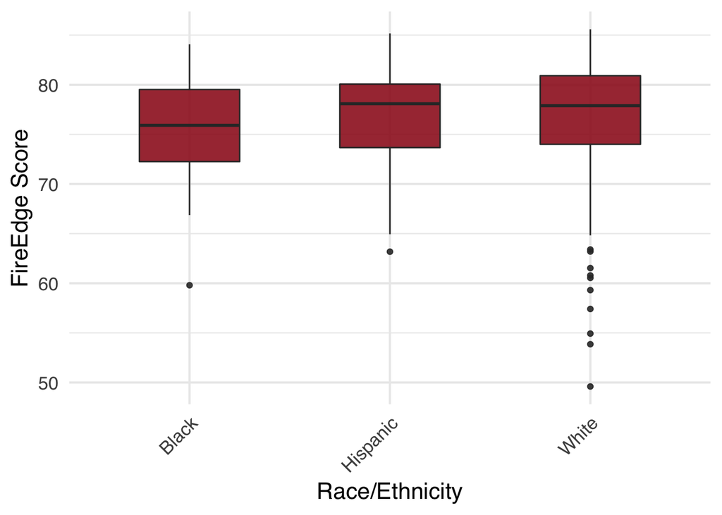

```r
val_data %>%
  filter(Race == "Black" | Race == "White" | Race == "Hispanic") %>%
  ggplot(aes(x=Race, y=FireEdge_Score)) +
  geom_boxplot(fill = "#9E1C24", width= 0.5, alpha = 0.9) +
  theme_minimal(base_size = 16,base_family = "sans") +
    labs(x = "Race/Ethnicity",
         y = "FireEdge Score") +
  theme(legend.position = "none", axis.text.x = element_text(angle = 45, hjust = 1))
```

## 7. Conclusion

This research study sought to investigate and establish a linear relationship between test scores on the *FireEdge* with ratings of job performance.

The conclusions reached based on the data and evidence were favorable, with a significant Pearson product moment correlation (*r* = .273) being calculated. Next, a linear regression model was run to regress test scores on job performance, which resulted in the line of best fit trending in an upward and positive direction. Finally, an analysis of variance was conducted in order to ascertain no bias existed in test scores across different races.

In summary, the conclusions reached in this study were significant, providing empirical evidence that the *FireEdge* does indeed predict job performance scores. Such information can be used to better inform the clients who use our products. The relationships established in this research study also lend credence to the entire process of developing our customized internal assessments, as the test content, when properly modeled, does predict a focal criteria of interest for clients. Further analyses could be conducted to determine facets of the *FireEdge* which do not predict as well as others, and attempt to iterate on the examination to help deliver an even better product or solution. Larger scale analyses could also be conducted after the test has been deployed to the population, with sample sizes into the thousands. We’d be able to re-calculate several of the statistics on a pre-established basis to ensure our test continues to function as intended once deployed to the population.